# Northern Three Spatial Analyses (eReefs Stars Method Workflow)

- Show All Code
- Hide All Code
- View Source

Author

Adam Shand

Published

October 27, 2023

**R Version**

For R session info at the time of rendering this script see Section 4.

**Note**

This is one part of several scripts exploring CSIRO ereefs data.

# 1 Introduction

This script provides a general workflow when using the stars R package for handling curvilinear eReefs datasets. The stars package boasts its ability to natively handling non-regular gridded datasets without mandating warping/transformations.

The script demonstrates how to:

- Download curvilinear data from the NCI database
- Perform generic data handling steps such querying, cropping, and saving
- Perform tasks such as mapping, and analysis

# 2 Script Set Up

This script requires multiple core spatial packages, all packages are loaded below.

```r
#load packages
library(stars)
library(ncmeta)
library(sf)
library(tidyverse)
library(ereefs)
library(here)
library(ggplot2)
library(viridis)
library(ggthemes)
library(tmap)
library(glue)
```

Then we also need to set up key variables for the script, as well as the output location.

```r
#set project crs
proj_crs <- params$project_crs

#create a file path to help with saving outputs
save_outputs <- here("outputs/n3_ereefs_s2_stars-method-workflow/")
save_data <- here("data/n3_ereefs_s2_stars-method-workflow/")

#bring the path to life
dir.create(save_outputs)
dir.create(save_data)

#write a note to the data folder
writeLines("No data is required for this script.", glue("{save_data}/note.txt"))

#turn off s2 geometry
sf_use_s2(FALSE)
```

# 3 Load Data

Now the script is set up we need to load in all of the required datasets. This will be broken into two segments:

- Spatial data specific to the N3 region - such as the region, basin, and sub basin boundaries.
- eReefs data

## 3.1 Spatial Data

Spatial data for the northern three regions should be readily available in the repo, the dataset is created by the n3_region-builder.qmd script in the repo that should be the first script run for new users. If the dataset is not available refer back to the README document in the GitHub repo. The other parts of spatial data here should go off without a hitch if the region-builder script has been run.

```r
#read in qld outlines data from the gisaimsr package, filter for land and islands, update crs
qld <- get(data("gbr_feat", package = "gisaimsr")) |> filter(FEAT_NAME %in% c("Mainland", "Island")) |>
  st_transform(proj_crs)

#read in the northern three spatial files and reduce down to only the components we need
n3_marine_region <- st_read(here("data/n3_region-builder/n3_region.gpkg")) |> filter(environment == "Marine")
```

## 3.2 eReefs Data - NCI version

Now we can download the NCI data from the server. We are going to download temperature data for the entire GBR, from a random date, at the surface, with 1/3 resolution. We are using temperature data as that is easy to “sanity check” and spot errors. The metadata for temperature looks like this:

```r
#establish the initial file path using the ereefs package
#input_file <- substitute_filename("catalog")
input_file <- "https://dapds00.nci.org.au/thredds/dodsC/fx3/GBR1_H2p0_B3p2_Cfur_Dnrt.ncml"

#read in file, use temp variable and get all lat long, pick surface (44) and a random date (100), downsample to reduce size
nc_temp <- read_ncdf(input_file, var = "temp",
                ncsub = cbind(start = c(1, 1, 44, 100),
                              count = c(510, 2388, 1, 1)),
                downsample = 2)

#look at dataset
nc_temp
```

```
stars object with 4 dimensions and 1 attribute
attribute(s):
               Min. 1st Qu.   Median    Mean  3rd Qu.     Max.  NA's
temp [°*C] 21.23004 29.0912 30.19137 29.9012 30.64592 33.10383 66725
dimension(s):
     from  to  refsys                  values x/y
i       1 170  WGS 84   [170x796] NaN,...,NaN [x]
j       1 796  WGS 84   [170x796] NaN,...,NaN [y]
k       1   1      NA                      44
time    1   1 POSIXct 2020-03-07 02:00:00 UTC
curvilinear grid
```

And the actual data visualized looks like this:

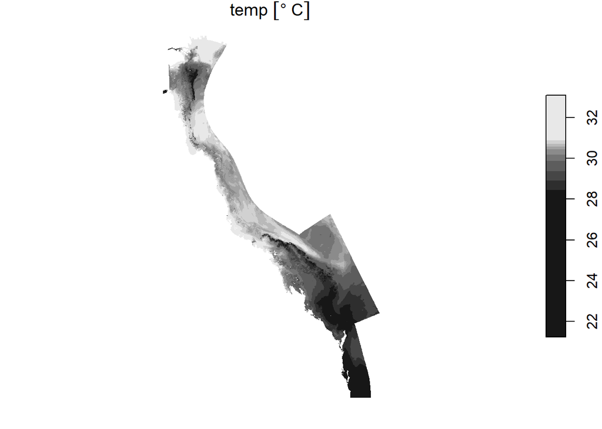

```r
#view
plot(nc_temp)
```

```r
#download chla data
nc_chla <- read_ncdf(input_file, var = "Chl_a_sum",
                ncsub = cbind(start = c(1, 1, 44, 100),
                              count = c(510, 2388, 1, 1)),
                downsample = 2)
```

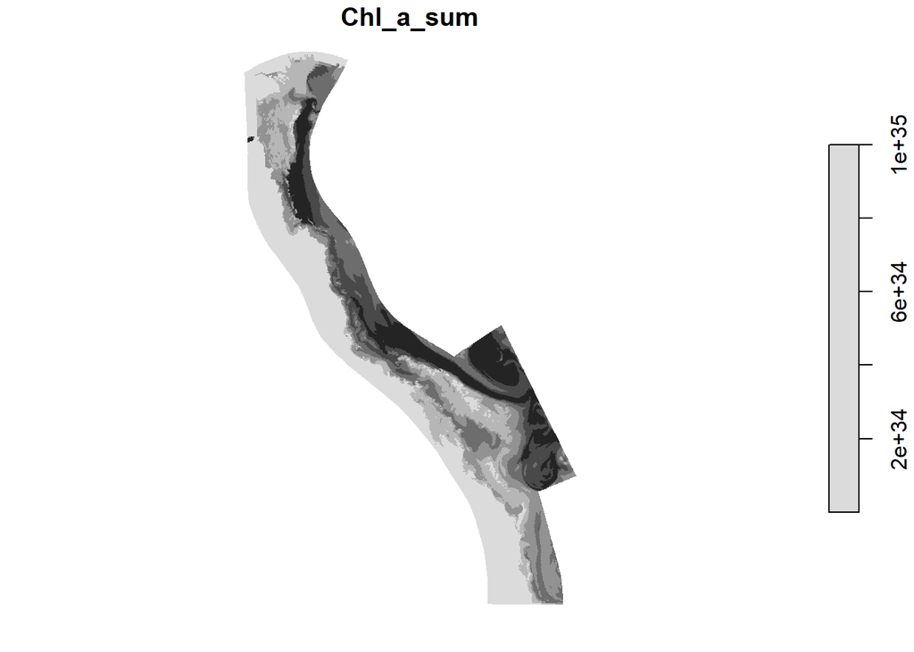

```r
#view
plot(nc_chla)
```

There is something wildly off about the scale. The cause of this is that for some reason the values that should be read as NA by the stars package are instead assigned incredibly high numbers such as 1e+35 (35 zeros to the left of the decimal). To give a better example of why this sucks, here it is mapped using my preferred tools:

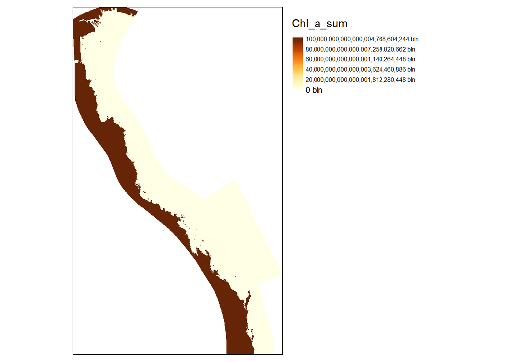

```r
tm_shape(nc_chla) +
  tm_raster(style = "cont", legend.reverse = T) +
  tm_layout(legend.outside = T)
```

Thankfully this can easily be fixed by setting all values above and arbitrary value to be NA.

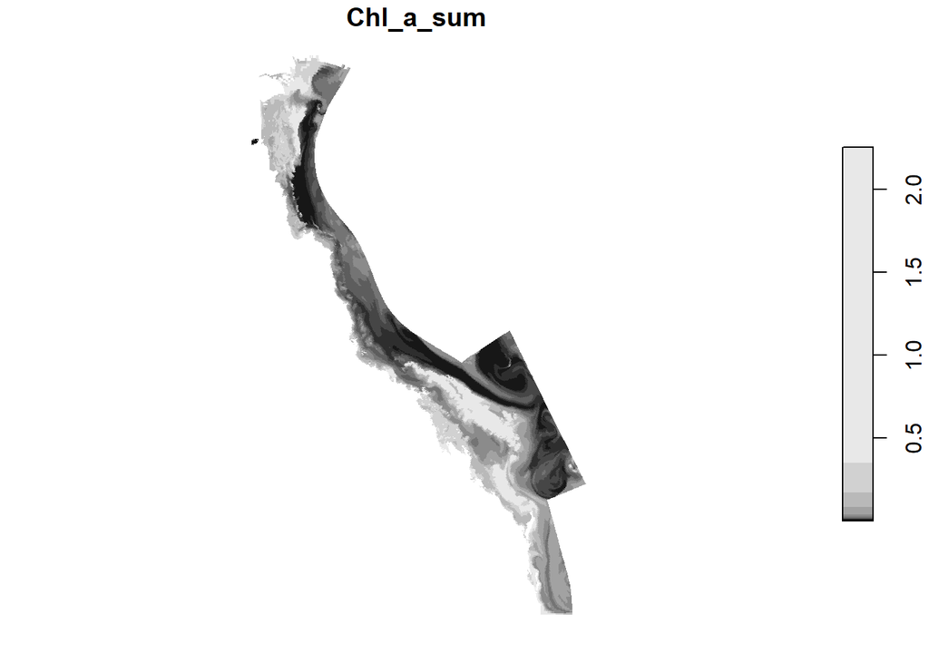

```r
#set values to NA
nc_chla[(nc_chla > 100)] <- NA

plot(nc_chla)
```

Fixed!

## 3.3 Testing functionality

Moving into testing we will perform a variety of actions on either the temperature or the chla dataset, noting that both should react the same way.

### 3.3.1 Warping

The first thing we want to cover is warping (and more importantly, why we cant warp currently). Basically when we attempt to warp the function is throwing an error because there are NA values within the lat and/or long values for the dataset. The first method returns the error:

```r
#create a grid for the data to be warped too
nc_temp_grid <- nc_temp |> st_transform(st_crs(nc_temp)) |> st_bbox() |> st_as_stars()

#attempt to warp data
nc_temp_warped <- st_warp(src = nc_temp, dest = nc_temp_grid, use_gdal = T)
```

```
Error in st_warp(src = nc_temp, dest = nc_temp_grid, use_gdal = T): for warping curvilinear grids using GDAL, use gdal_utils("warp",...) directly on the source dataset of this object
```

And the follow up from this error returns the new error:

```r
#try the gdal method
gdal_utils(util = "warp", source = "nc_temp", destination = paste0(tempfile(), ".nc"))
```

```
Error in gdal_utils(util = "warp", source = "nc_temp", destination = paste0(tempfile(), : gdal_utils warp: an error occured
```

Which we believe is caused by NA values. Currently we have no good way of replacing NA values with the correct coordinates.

### 3.3.2 Plotting

As you might have noticed above, we can of course do basic mapping using native R functions:

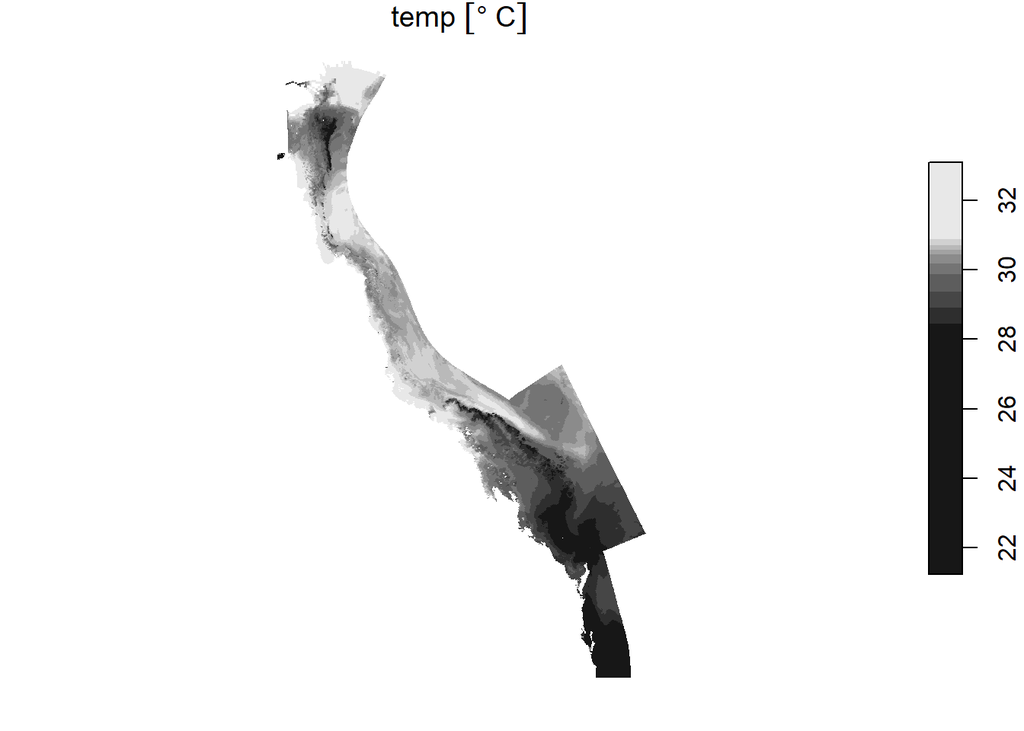

```r
plot(nc_temp)
```

However what we really want to know if how hard it is to manipulate the maps. Looks like we can use ggplot:

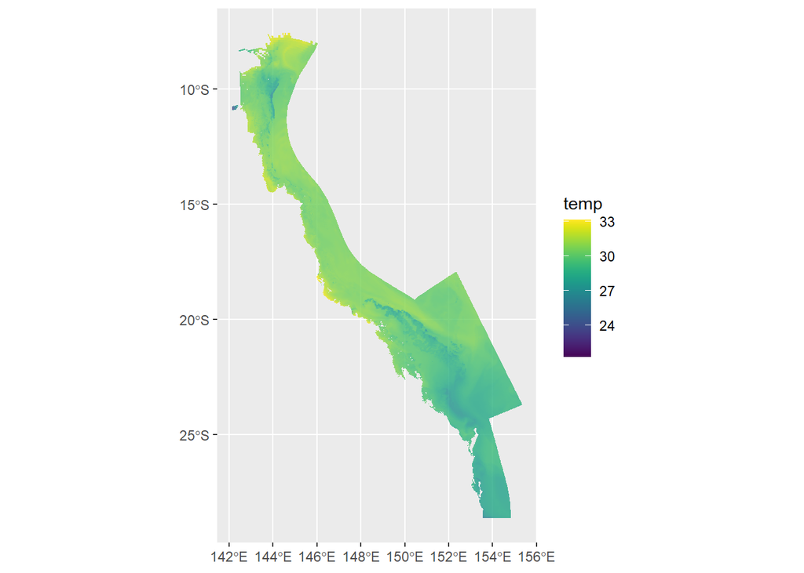

```r
ggplot() +
  geom_stars(data = nc_temp[1], alpha = 0.8) +
  scale_fill_viridis()
```

And, thankfully, we can also use tmap - my favorite.

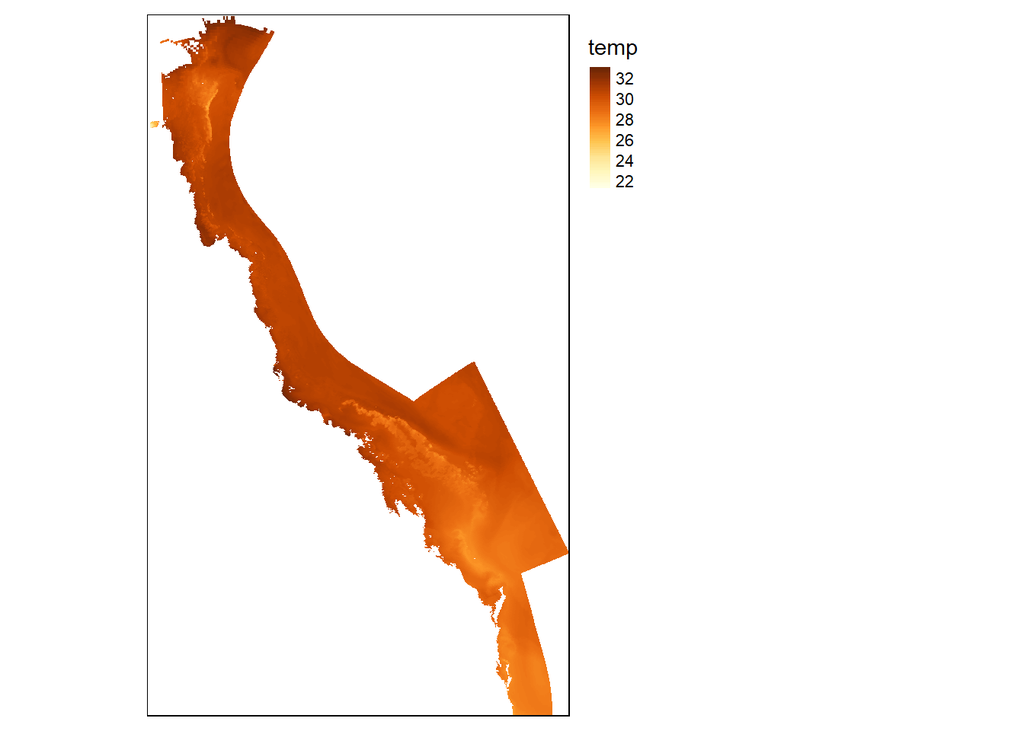

```r
tm_shape(nc_temp) +
  tm_raster(style = "cont", legend.reverse = T) +
  tm_layout(legend.outside = T)
```

### 3.3.3 Cropping

It is one thing to be able to map, but what about mapping the location that we want (via cropping)?

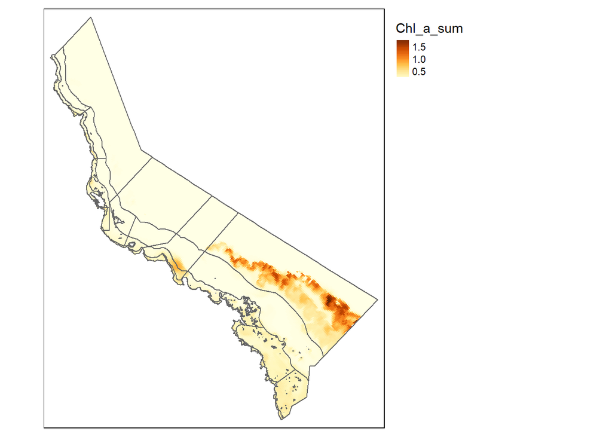

```r
#update crs
nc_chla <- st_transform(nc_chla, proj_crs)

#crop
nc_chla_n3 <- st_crop(nc_chla, n3_marine_region, na.rm = T)

#plot
tm_shape(nc_chla_n3) +
  tm_raster(style = "cont", legend.reverse = T) +
  tm_layout(legend.outside = T) +
  tm_shape(n3_marine_region, is.master = T) +
  tm_borders()
```

…Kinda, we can “crop” the data by making all cells outside the area NA, but they are still there. So the extend remains unchanged. To be able to zoom into our cropped location we have to make our cropping layer the master layer.

Below is a slightly pretty version, that we will also save.

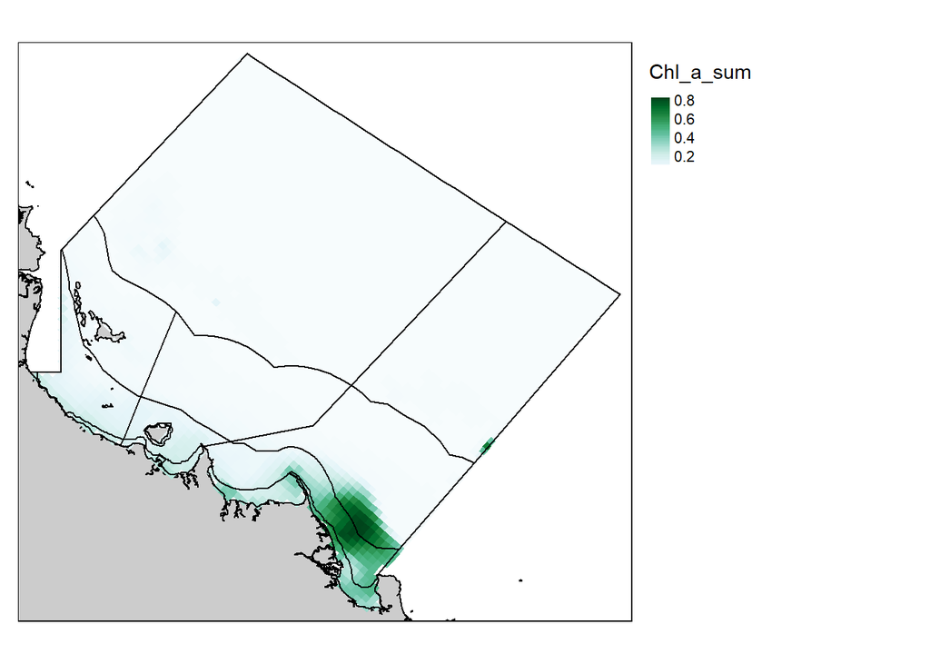

```r
#cut to only DT area
dt_region <- n3_marine_region |> filter(region %in% c("Dry Tropics", "Burdekin"))

#crop to the area
nc_chla_dt <- st_crop(nc_chla_n3, dt_region, na.rm = T)

#plot
dt_map <- tm_shape(qld) +
  tm_polygons(col = "grey80", border.col = "black") +
  tm_shape(nc_chla_dt) +
  tm_raster(style = "cont", legend.reverse = T, palette = "BuGn") +
  tm_layout(legend.outside = T) +
  tm_shape(dt_region, is.master = T) +
  tm_borders(col = "black")

dt_map
```

```r
tmap_save(dt_map, glue("{save_outputs}/dt_example_map.png"))
```

#### 3.3.3.1 Cropping: AIMS/stars Version

However this brings up a new challenge to think about. If we are trying to get multiple datasets (time steps) for a small area, do we have to download the entire GBR for each date and then convert values to NA? This would be quite slow.

Thankfully, there is a new method that has been identified that utilizes the internals of an aims ereefs function, and the stars download method to pre-crop data before downloading. First we use the a very handy function `get_ereefs_grids()` to pull in all grid information (x y and z). These are named matrices of all lat (y) and long (x) values.

```r
#get all grids
grids <- get_ereefs_grids(input_file)

#show names
names(grids)
```

```
[1] "x_grid" "y_grid" "z_grid"
```

```r
#get x and y specifically
x_grid <- grids[["x_grid"]]
y_grid <- grids[["y_grid"]]
```

Once we have these matrices we then need to find the position of the lats and longs in these matrices that best match our cropping boundaries. To do this we will:

- create an array of TRUE/FALSE values the same size as the matrices + assign TRUE to the array if the grid value in that same positions is outside our boundary + assign FALSE to the array if the grid value in that same positions is inside our boundary

```r
#set bounding box, order is min lon, max lon, min lat, max lat
box_bounds <- c(145, 150, -22, -16)

#create an array of FALSE values the same dimensions as the x (and y) grids
outOfBox <- array(FALSE, dim = dim(x_grid))

#change array value to TRUE if the associated value in the x or y grid at the same position is outside our bounding box
if (!is.na(box_bounds[1])) {outOfBox <- apply(x_grid, 2, function(x) {(x < box_bounds[1] | is.na(x))})}
if (!is.na(box_bounds[2])) {outOfBox <- outOfBox | apply(x_grid, 2, function(x) {(x > box_bounds[2] | is.na(x))})}
if (!is.na(box_bounds[3])) {outOfBox <- outOfBox | apply(y_grid, 2, function(x) {(x < box_bounds[3] | is.na(x))})}
if (!is.na(box_bounds[4])) {outOfBox <- outOfBox | apply(y_grid, 2, function(x) {(x > box_bounds[4] | is.na(x))})}
```

Then once we have this T/F array (which has more than a million entries btw) we invert the T/F vals and ask:

- what is the first instance of a row having at least one TRUE val
- how may rows have at least one T val
- what is the first instance of a col having at least one TRUE val
- how many cols have at least one T val

```r
#for apply(): first arg is an array, second arg is "margin" (how to apply func), 1 = rows, 2 = columns, third arg is the func to apply
#we invert the TRUE/FALSE vals in array using "!"
#we use any() to ask which values are true
#we use which() to return the position of true values in a vector array
#we use [1] to take first entry (not suppling a [] arg returns all entries)

#find the first x position (row) that is inside the bounding box (i.e. the first row with at least one TRUE val)
xmin <- which(apply(!outOfBox, 1, any))[1]

#find all (rows) inside the bounding box (i.e. all rows with at least one TRUE val) then take the last using length() as the index
xmax <- which(apply(!outOfBox, 1, any))
xmax <- xmax[length(xmax)]

#find the first y position (col) that is inside the bounding box (i.e. the first col with at least one TRUE val)
ymin <- which(apply(!outOfBox, 2, any))[1]

#find all (cols) inside the bounding box (i.e. all cols with at least one TRUE val) then take the last using length() as the index
ymax <- which(apply(!outOfBox, 2, any))
ymax <- ymax[length(ymax)]
```

Using this output we can then have our coords translated into the start and count values that are used to query NetCDF files.

```r
#extract cropped version
nc_chla_pre_cropped <- read_ncdf(input_file, var = "Chl_a_sum",
                                 ncsub = cbind(start = c(xmin, ymin, 44, 100),
                                               count = c((xmax - xmin), (ymax - ymin), 1, 1)))
```

and plotted.

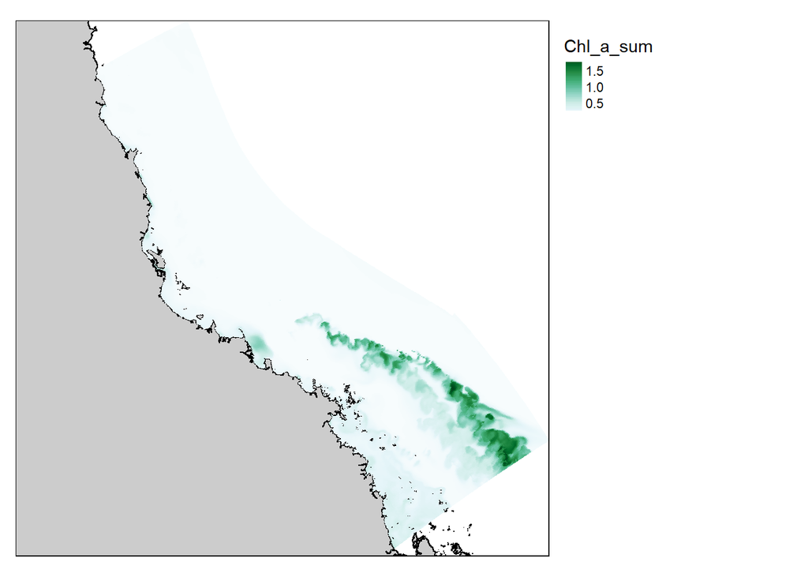

```r
#update crs
nc_chla_pre_cropped <- st_transform(nc_chla_pre_cropped, proj_crs)

#overwrite the "fake" NA values
nc_chla_pre_cropped[(nc_chla_pre_cropped > 100)] <- NA

#plot
tm_shape(qld) +
  tm_polygons(col = "grey80", border.col = "black") +
  tm_shape(nc_chla_pre_cropped, is.master = T) +
  tm_raster(style = "cont", legend.reverse = T, palette = "BuGn") +
  tm_layout(legend.outside = T)
```

### 3.3.4 Extracting Values

The final thing that we are concerned about is if we can extract values, both as a point, and as a mean of a random area.

```r
#create a point
pnt <- st_sfc(st_point(c(146.4346, -18.8168)), crs = st_crs(nc_temp))

#extract a value
extracted_val <- st_extract(nc_temp, pnt)

#get area versions
area_from_point <- function(numeric_pair, area = 0.15){
  coord_out <- st_polygon(list(cbind(c(numeric_pair[1] - area/2, numeric_pair[1] - area/2,
                                       numeric_pair[1] + area/2, numeric_pair[1] + area/2,
                                       numeric_pair[1] - area/2),
                                     c(numeric_pair[2] + area/2, numeric_pair[2] - area/2,
                                       numeric_pair[2] - area/2, numeric_pair[2] + area/2,
                                       numeric_pair[2] + area/2)))) |> st_sfc(crs = st_crs(nc_temp))
  }

#run function
poly <- area_from_point(c(146.4346, -18.8168))

#extract a value
extracted_val_2 <- st_extract(nc_temp, poly, fun = mean)

extracted_val
```

```
Simple feature collection with 1 feature and 2 fields
Geometry type: POINT
Dimension:     XY
Bounding box:  xmin: 146.4346 ymin: -18.8168 xmax: 146.4346 ymax: -18.8168
Geodetic CRS:  WGS 84
            temp                  geometry     min_dist
1 32.04305 [°*C] POINT (146.4346 -18.8168) 762.0206 [m]
```

Both of which appear to be possible.

```r
extracted_val_2
```

```
stars object with 3 dimensions and 1 attribute
attribute(s):
               Min.  1st Qu.   Median     Mean  3rd Qu.     Max.
temp [°*C] 32.08097 32.08097 32.08097 32.08097 32.08097 32.08097
dimension(s):
         from to  refsys point                         values
geometry    1  1  WGS 84 FALSE POLYGON ((146.4 -18.74, 146...
k           1  1      NA    NA                             44
time        1  1 POSIXct    NA        2020-03-07 02:00:00 UTC
```

Here is an example of multiple point extraction as well.

```r
#create a list of points
pnts <- st_as_sf(
  x = data.frame(point = c("1","2","3"), lon = seq(146.4346, 146.4746, 0.02), lat = seq(-18.8598, -18.8198, 0.02)),
  coords = c("lon", "lat"),
  crs = st_crs(nc_temp)
  )

#extract a value
extracted_val_3 <- st_extract(nc_temp, pnts)
```

And in a nice tabular format as well.

```r
pres_tbl <- extracted_val_3 |> select(temp)

data.frame(pres_tbl)
```

```
            temp                  geometry
1 32.11810 [°*C] POINT (146.4346 -18.8598)
2 31.95943 [°*C] POINT (146.4546 -18.8398)
3 31.87750 [°*C] POINT (146.4746 -18.8198)
```

#### 3.3.4.1 Exracting Values: AIMS/stars Version

We have also identified a new method mixing stars and aims together that does not require the full dataset to be downloaded first. Steps are as follows:

- Use the aims `get_params()` function to extract a full list of lat and long values
- Match our point coords to lat and long values and extract their position in the lat/long lists
- Use the positions to extract a point value from the NetCDF data without having to download the full data

```r
#create a dataframe of a lat and lon value
location_latlon = data.frame(latitude = -21.1488, longitude = 150.9397)

#create an arbitrary start and end date - this is just to satisfy the get_params() function, we dont actually use the dates
start_date <- c(2023, 02, 12)
end_date <- c(2023, 02, 12)

#extract parameters (we only car about the latitude and longitude extracts)
ereefs:::assignList(ereefs:::get_params(start_date, end_date, input_file, "temp"))

#determine the index of the point coord
grid_index <- apply(location_latlon, 1, function(ll) which.min((latitude - ll[1])^2 + (longitude - ll[2])^2))

#convert this index into a grid point
location_grid <- cbind(floor((grid_index + dim(latitude)[1] - 1)/dim(latitude)[1]),
                       (grid_index + dim(latitude)[1] - 1)%%dim(latitude)[1] + 1)

#download data at the specific grid point
nc_temp_point <- read_ncdf(input_file, var = "temp",
                ncsub = cbind(start = c(location_grid[2], location_grid[1], 44, 100),
                              count = c(1, 1, 1, 1)))
#show as a stars object
nc_temp_point
```

```
stars object with 4 dimensions and 1 attribute
attribute(s):
               Min.  1st Qu.   Median     Mean  3rd Qu.     Max.
temp [°*C] 29.26572 29.26572 29.26572 29.26572 29.26572 29.26572
dimension(s):
     from to  refsys                  values x/y
i       1  1  WGS 84                   150.9 [x]
j       1  1  WGS 84                  -21.15 [y]
k       1  1      NA                      44
time    1  1 POSIXct 2020-03-07 02:00:00 UTC
curvilinear grid
```

```r
#and as a dataframe
data.frame(nc_temp_point)
```

```
         i         j  k                time           temp
1 150.9387 -21.14757 44 2020-03-07 02:00:00 29.26572 [°*C]
```

So in summary, it now appears that a transformation of the curvilinear grid is no longer required for any aspect of the work that we intend to do, from mapping to data extraction and analysis. We can do it all.

# 4 Session Info

Below is the session info at the time of rendering this script. Of greatest importance is to note the R version, and the “other attached packages” as these are the most significant drivers of success/failure. It is also good to check the “attached base packages” and “loaded via a namespace” packages as well. To check your session info use `sessionInfo()`.

[session information not shown]